```
---
title: "Cross-Validation to Find Optimal Probability Benchmark"
author: Alvin Alexander
output:
  html_document:
    number_sections: true
---
```

## INTRODUCTION

The purpose of this file is to find the optimal probability threshold to binarise the predicted probabilities from each model into either 0s or 1s representing gold predictions. It works through k-fold cross validation where I create five folds of the training data. Five iterations are run for each model where k-1 folds are used as training and the other one is used as testing. For each iteration, I create the appropriate model and evaluate the F1-score across several different probability thresholds. After running all the iterations, I calculate the average F1-score for each probability threshold and plot them accordingly. Where the F-1 score is maximised, that is the benchmark probability that I will be using.

Note: F1-score is an evaluation metric combines both the precision (the proportion of true positives among all the positives made by the model) and recall (the proportion of true positives among all the actual positives). It measures the tradeoff between these two metrics and ultimately shows that the model can correctly identify positive cases while minimising false positives and false negatives.

The formula for the metric is below:
$$\text{F1-Score} = 2 \times \frac{\text{Precision} \times
\text{Recall}}{\text{Precision} + \text{Recall}}$$
Where

$$\text{Precision} = \frac{\text{True Positives (TP)}}{\text{True
Positives (TP)} + \text{False Positives (FP)}}$$

$$\text{Recall} = \frac{\text{True Positives (TP)}}{\text{True Positives
(TP)} + \text{False Negatives (FN)}}$$

## LOGISTIC REGRESSION

```
##    threshold  f1_score
## 1       0.30 0.9347945
## 2       0.35 0.9345096
## 3       0.40 0.9345929
## 4       0.45 0.9341299
## 5       0.50 0.9342234
## 6       0.55 0.9318693
## 7       0.60 0.9301286
## 8       0.65 0.9264533
## 9       0.70 0.9223957
## 10      0.75 0.9172847
## 11      0.80 0.8910200
## 12      0.85 0.8910891
## 13      0.90 0.8910891
## 14      0.95 0.8910891
## 15      1.00 0.8910891
```

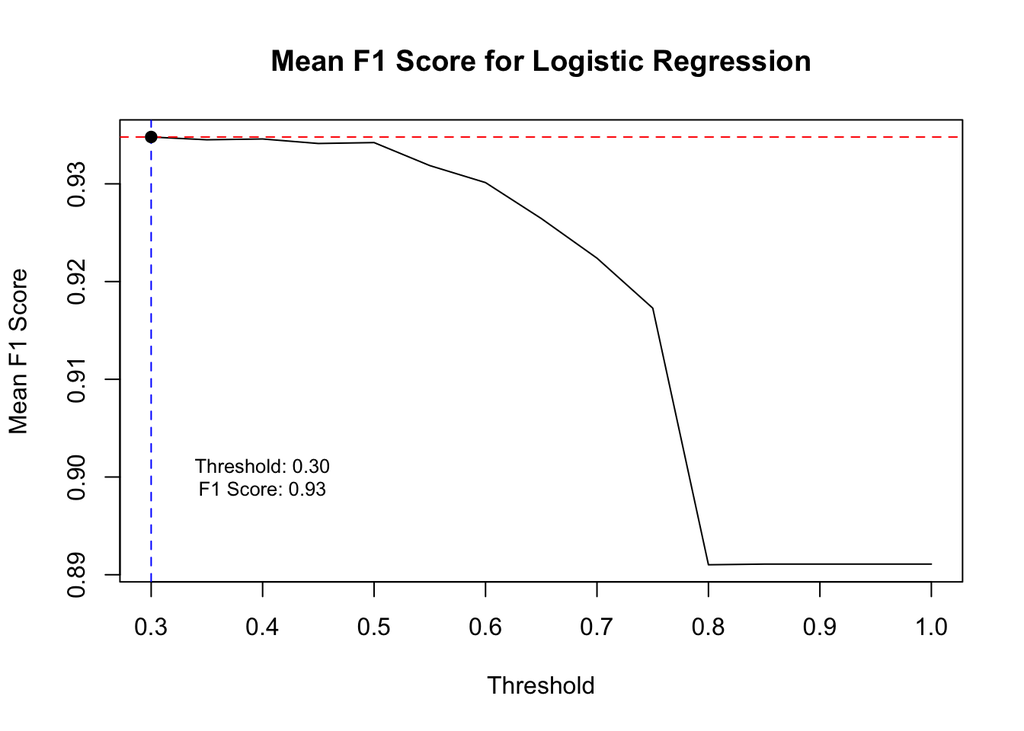

# SVM

```
##    threshold  f1_score
## 1       0.30 0.9347766
## 2       0.35 0.9347766
## 3       0.40 0.9347766
## 4       0.45 0.9347766
## 5       0.50 0.9347766
## 6       0.55 0.9347766
## 7       0.60 0.9347766
## 8       0.65 0.9347766
## 9       0.70 0.9350035
## 10      0.75 0.8910891
## 11      0.80 0.8910891
## 12      0.85 0.8910891
## 13      0.90 0.8910891
## 14      0.95 0.8910891
## 15      1.00 0.8910891
```

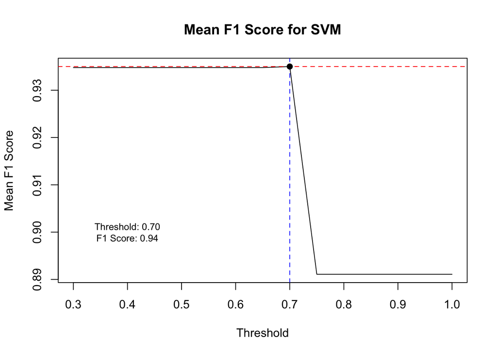

## RANDOM FOREST

```
##    threshold  f1_score
## 1       0.30 0.9370124
## 2       0.35 0.9388658
## 3       0.40 0.9390547
## 4       0.45 0.9384829
## 5       0.50 0.9384829
## 6       0.55 0.9384829
## 7       0.60 0.9387295
## 8       0.65 0.9423393
## 9       0.70 0.9427186
## 10      0.75 0.9412805
## 11      0.80 0.9366272
## 12      0.85 0.9363909
## 13      0.90 0.9333943
## 14      0.95 0.9287340
## 15      1.00 0.9163779
```

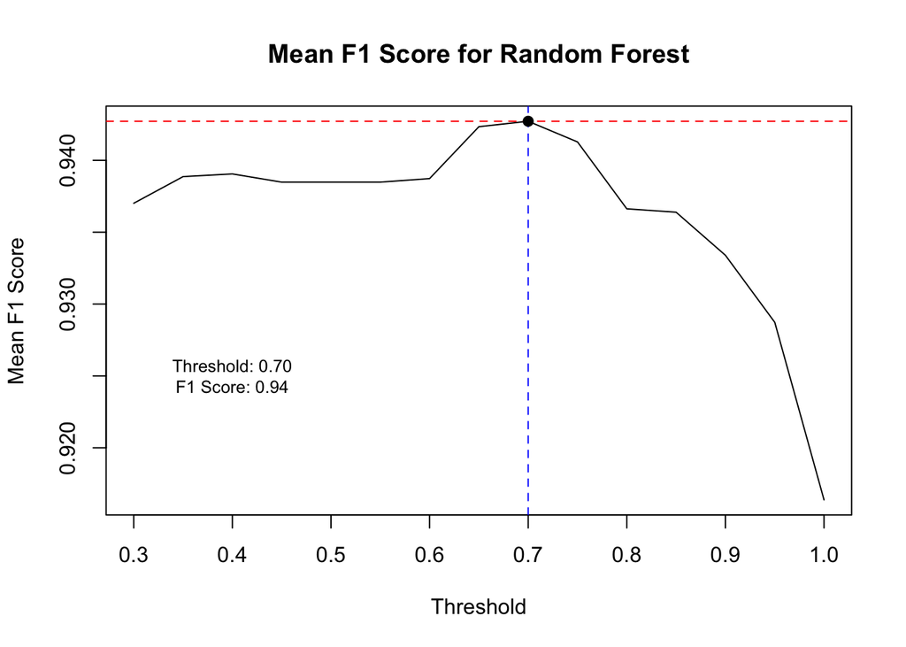

## KNN

```
##    threshold  f1_score
## 1       0.30 0.9265489
## 2       0.35 0.9371751
## 3       0.40 0.9416491
## 4       0.45 0.9421300
## 5       0.50 0.9435361
## 6       0.55 0.9416680
## 7       0.60 0.9414399
## 8       0.65 0.9391167
## 9       0.70 0.9343088
## 10      0.75 0.9345789
## 11      0.80 0.9282295
## 12      0.85 0.9152889
## 13      0.90 0.9150633
## 14      0.95 0.9065101
## 15      1.00 0.9065101
```

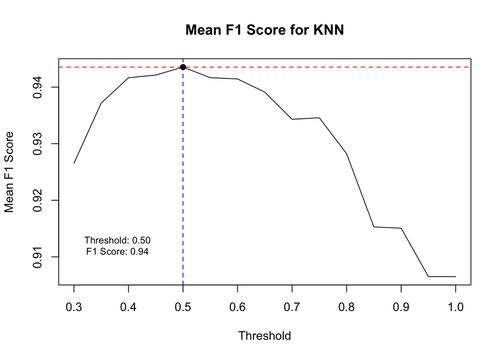

## BOOSTING

```
##    threshold  f1_score
## 1       0.30 0.9323514
## 2       0.35 0.9347682
## 3       0.40 0.9376163
## 4       0.45 0.9382776
## 5       0.50 0.9396584
## 6       0.55 0.9391663
## 7       0.60 0.9413843
## 8       0.65 0.9398357
## 9       0.70 0.9347216
## 10      0.75 0.9239848
## 11      0.80 0.9155541
## 12      0.85 0.9002292
## 13      0.90 0.8968335
## 14      0.95 0.8936503
## 15      1.00 0.8910891
```

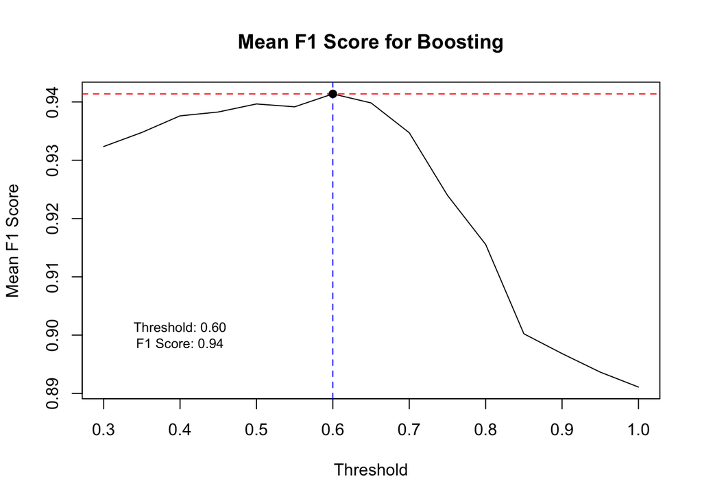